# Лабораторная работа №1

Работа с git

Дворкина Е. В.

Российский университет дружбы народов, Москва, Россия

22 февраля 2025

## Докладчик

- Дворкина Ева Владимировна
- студентка
- группа НФИбд-01-22
- Российский университет дружбы народов
- 1132226447@rudn.ru
- https://github.com/evdvorkina

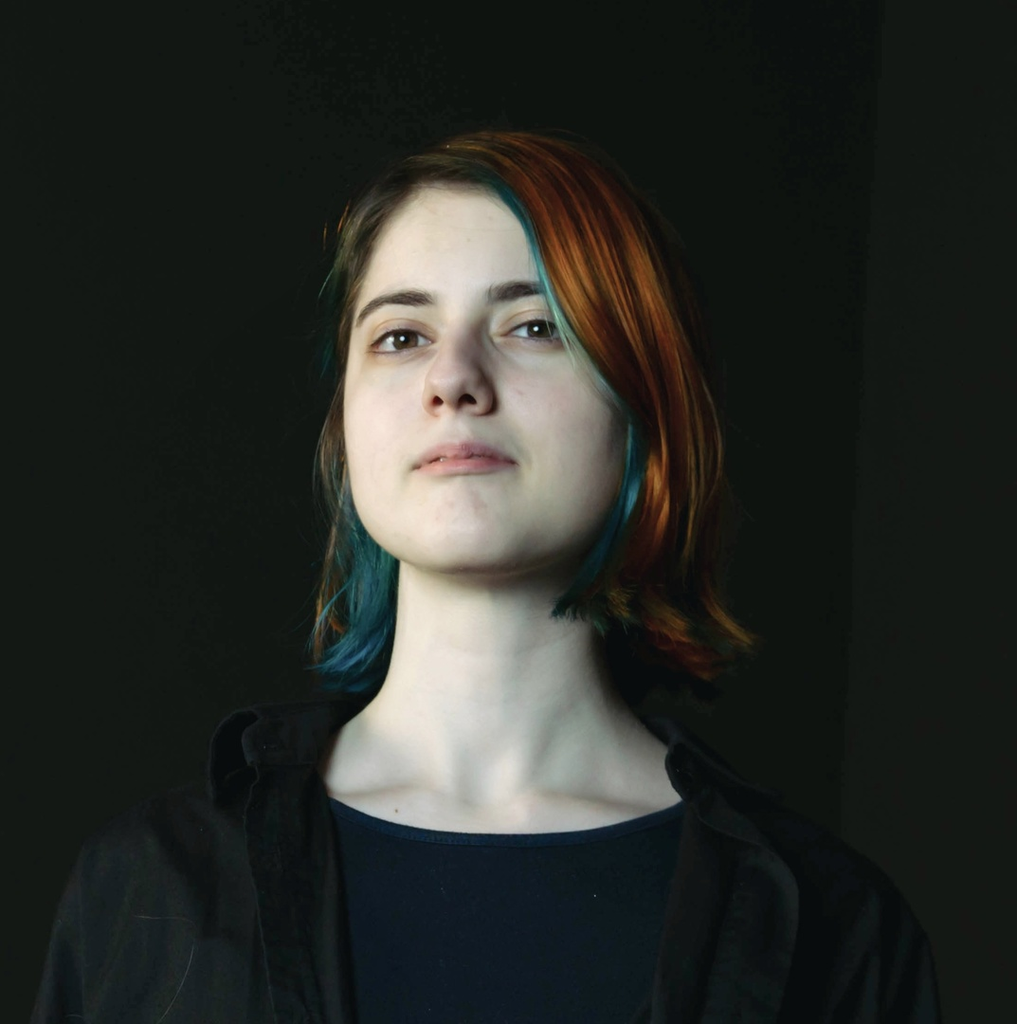

## Цель работы

Цель данной лабораторной работы - приобретение практических навыков работы с системой управления версиями Git.

# Теоретическое введение

Git — распределённая система управления версиями. Проект был создан Линусом Торвальдсом для управления разработкой ядра Linux, первая версия выпущена 7 апреля 2005 года; координатор — Дзюн Хамано.

# Выполнение лабораторной работы

## Подготовка

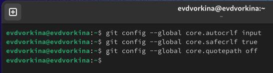

Настройка git

## Создание проекта

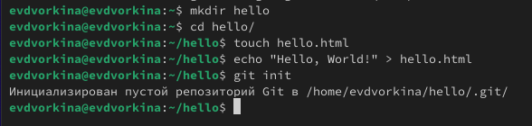

Создание репозитория

## Создание проекта

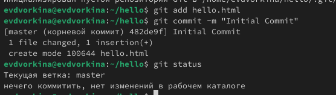

Добавление файла в репозиторий

## Внесение изменений

Изменим содержимое файла hello.html на:

```
<h1>Hello, World!</h1>
```

## Внесение изменений

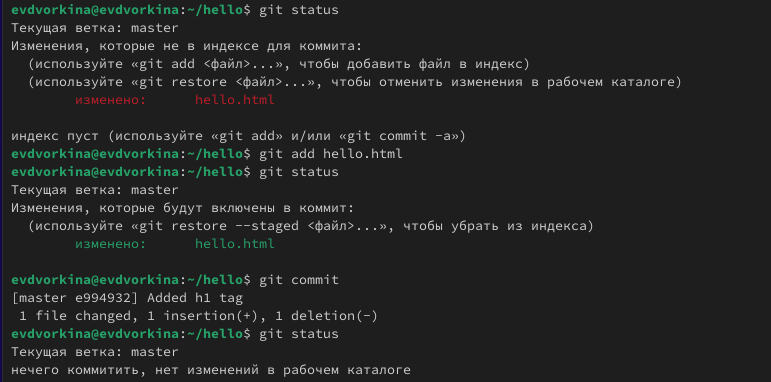

Внесение изменений в содержимое репозитория

## Внесение изменений

```
<html>
  <body>
    <h1>Hello, World!</h1>
  </body>
</html>
```

## Внесение изменений

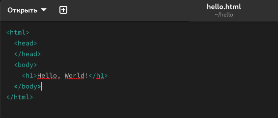

Изменение файла hello.html

## Внесение изменений

Проверив текущий статус, увидим, что hello.html указан дважды в состоянии. Первое изменение (добавление стандартных тегов) проиндексировано и готово к коммиту. Второе изменение (добавление заголовков HTML) не проиндексированно.

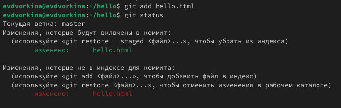

Внесение нескольких изменений в содержимое репозитория

## Внесение изменений

Произведем коммит проиндексированного изменения. Проиндексируем оставшееся изменение, посмотрим статус и прокоммитим его тоже

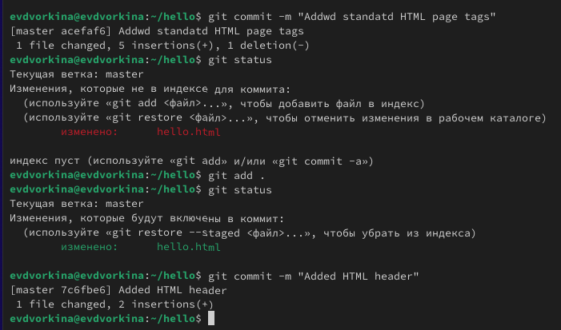

Внесение нескольких изменений в содержимое репозитория

## История

Получим список произведенных изменений в стандартном виде `git log`, затем в однострочном `git log --pretty=oneline` и далее с указанием времени и количества

```
git log --pretty=oneline --max-count=2
git log --pretty=oneline --since='5 minutes ago'
git log --pretty=oneline --until='5 minutes ago'
```

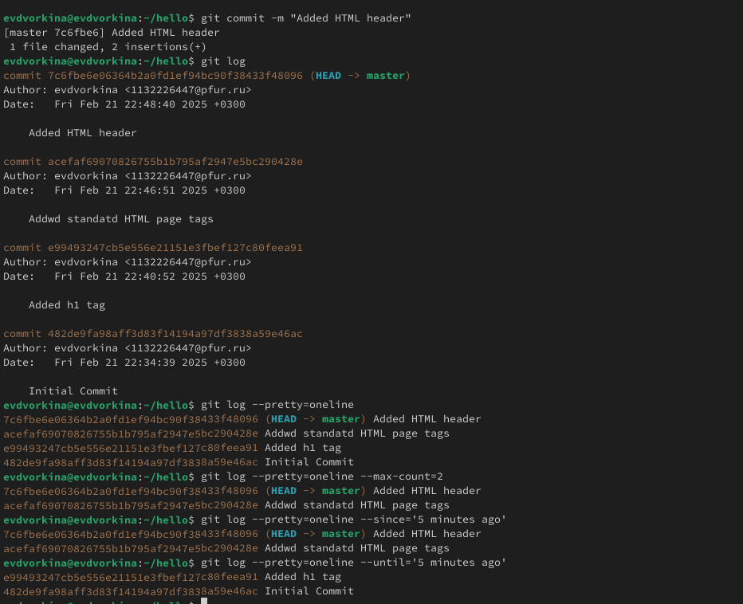

Просмотр истории

## Получение старых версий

Изучим данные лога и найдем там хэш первого коммита, используя его, вернемся к первой верссии репозитория и просмотрим файл hello.html, действительно, увидим первую версию. Затем вернемся к последней версии в ветке master и посмотрим на тот же файл

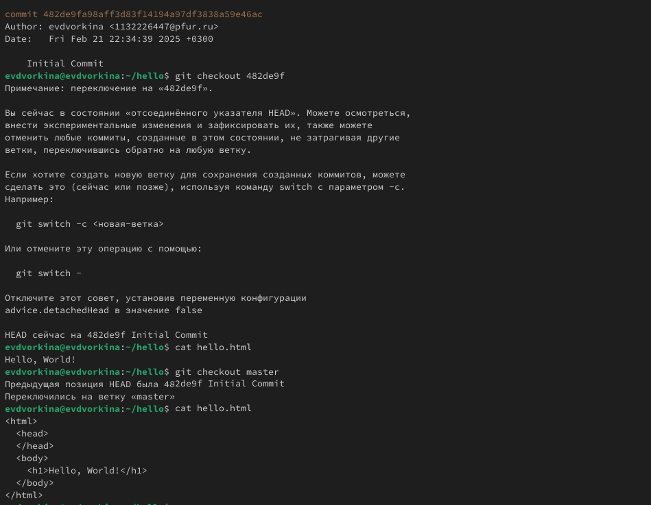

Просмотр разных версий репозитория

## Создание тегов версий

Назовем текущую версию страницы hello первой (v1). Создадим тег первой версии `git tag v1` и используем его для того, чтобы вернуться к предыдущей версии, которой также присвоим тег v1-beta

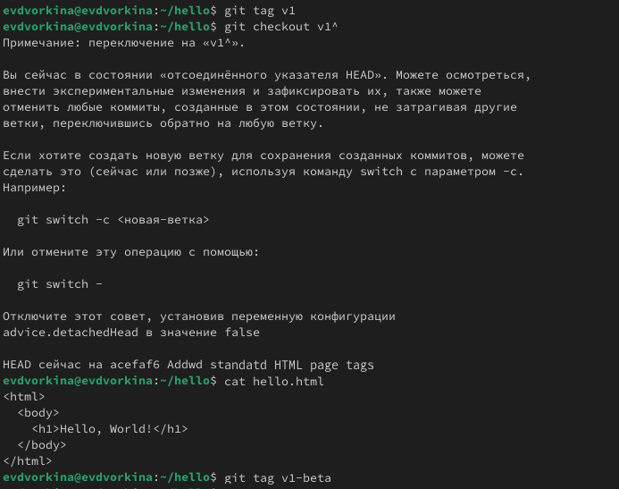

Создание тегов версий

## Создание тегов версий

Переключимся по тегам между двумя отмеченными версиями. Просмотрим все доступные теги (их два) и посмотрим теги в логе

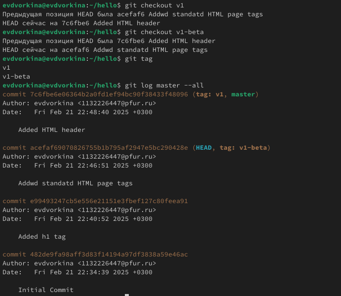

Переключение по имени тега и просмотр доступных тегов

## Отмена локальных изменений (до индексации)

Убдеимся, что мы находимся на последнем коммите ветки master и внесем изменение в файл hello.html в виде нежелательного комментария

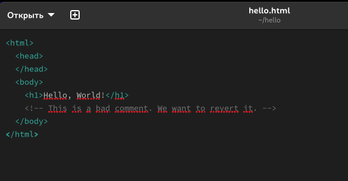

Внесение нежелательного комментария в hello.html (до индексации)

## Отмена локальных изменений (до индексации)

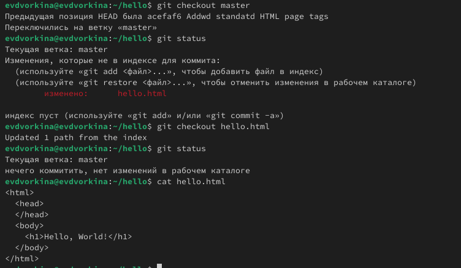

Отмена локальных изменений (до индексации)

## Отмена проиндексированных изменений (перед коммитом)

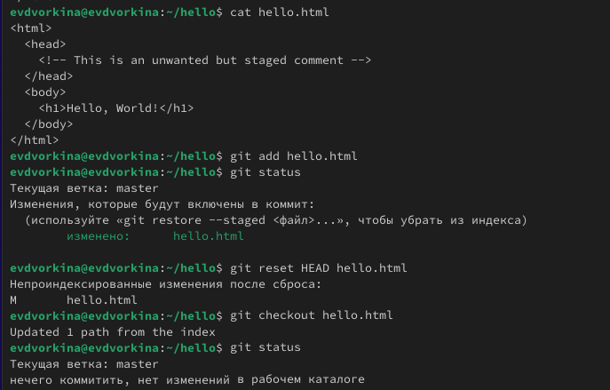

Отмена проиндексированных изменений (перед коммитом)

## Отмена коммитов

Изменим файл hello.html на следующий.

```
<html>
  <head>
  </head>
  <body>
    <h1>Hello, World!</h1>
    <!-- This is an unwanted but committed change -->
  </body>
</html>
```

## Отмена коммитов

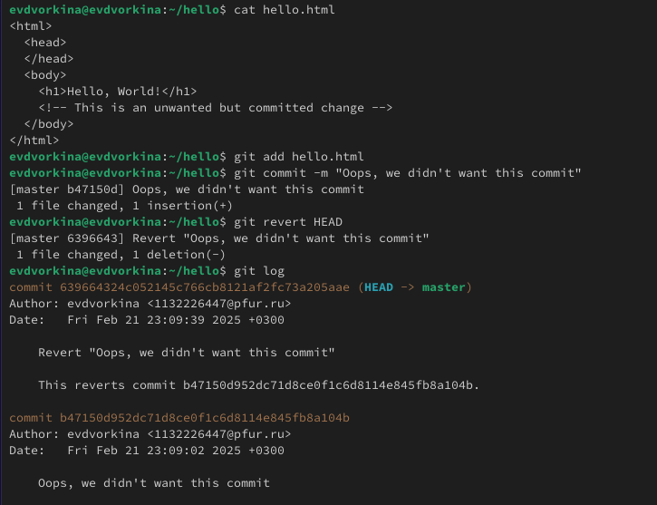

Отмена коммитов

## Удаление коммиттов из ветки

Удалим последние два коммита с помощью сброса, сначала отметим последний коммит тегом, чтобы его можно было потом найти. Используем команду`git reser --hard v1`, чтобы вернуться к версии до этих коммитов.

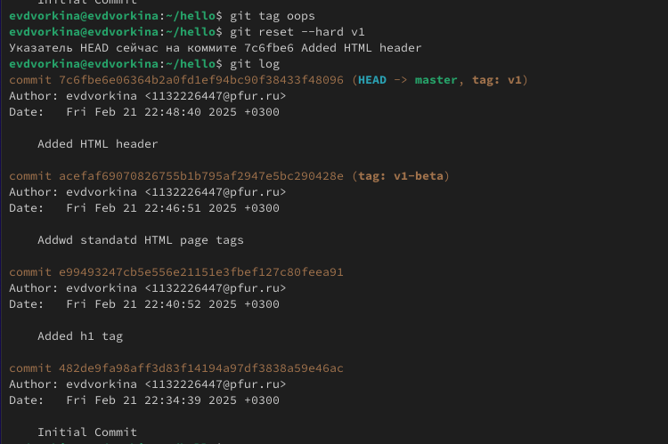

Удаление коммиттов из ветки

## Удаление коммиттов из ветки

Теперь в логе их нет, но если посмотреть логи с опцией `--all` можно их увидеть.

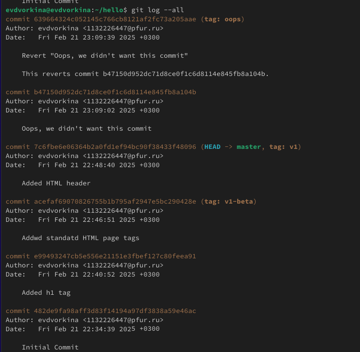

Ничего никогда не теряется

## Удаление тега oops

Удалим тег oops и коммиты, на которые он ссылался, сборщиком мусора. Теперь этот тег не отображается в репозитории

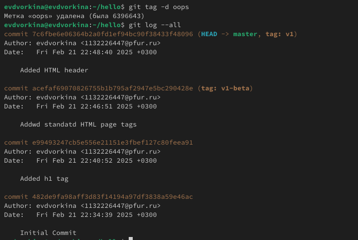

Удаление тега oops

## Изменение предыдущего коммита

Добавим в страницу комментарий автора

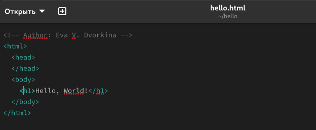

Изменение файла hello.html

## Изменение предыдущего коммита

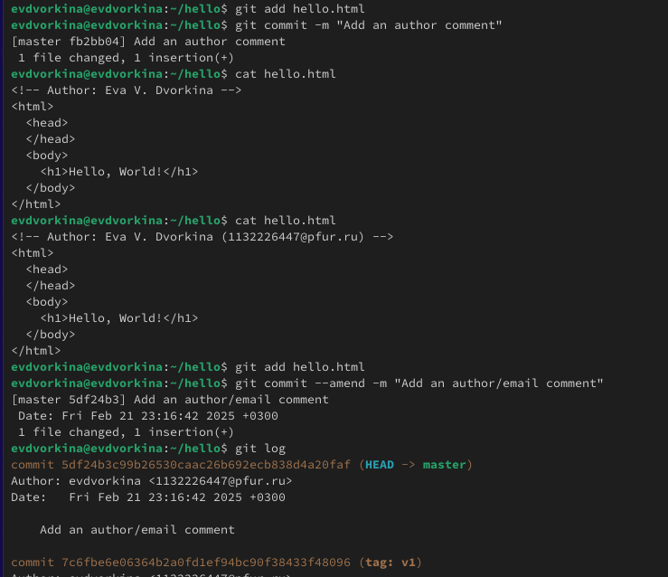

Изменение предыдущего коммита

## Перемещение файлов

Переместим наш файл в каталог lib. Для этого создадим его и используем команду `git mv`, сделаем коммит этого перемещения

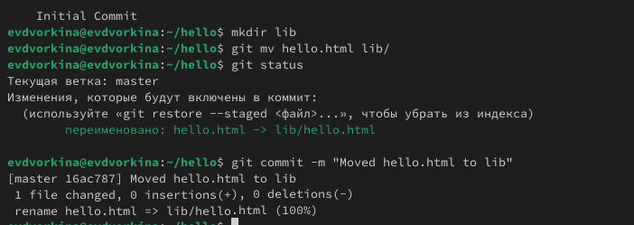

Создание структуры репозитория

## Подробнее о структуре

Добавим файл index.html в наш репозиторий, заполним файл:

```
<html>
  <body>
    <iframe src="lib/hello.html" width="200" height="200" />
  </body>
</html>
```

## Подробнее о структуре

Проиндексируем файл и сделаем коммит

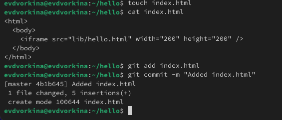

Создание, индексация, коммит нового файла

## Подробнее о структуре

Теперь при открытии index.html увидим кусок страницы hello в маленьком окошке

[figure not shown]

Результат открытия index.html

## Git внутри: Каталог .git

Просмотрим каталог, в котором хранится вся информация git. `ls -C .git/`

Затем посмотрим набор каталогов, имена которых состоят из 2 символов `ls -C .git/objects`

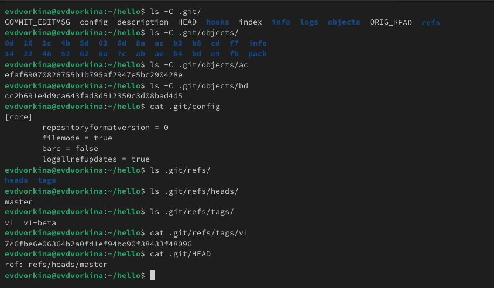

Каталог .git

## Работа непосредственно с объектами git

Найдем последний коммит через `log` и выедем его, используя SHA1 хэш.

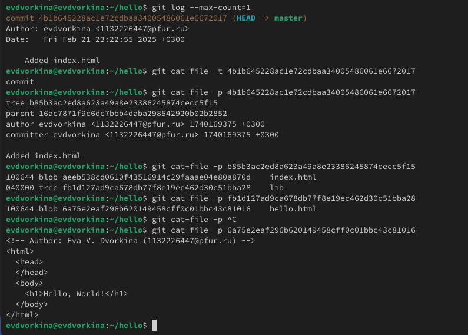

Работа непосредственно с объектами git

Исследуем git репозиторий вручную самостоятельно. Используя хэш родительского коммита последовательно дойдем до первой версии файла hello.html и посмотрим его

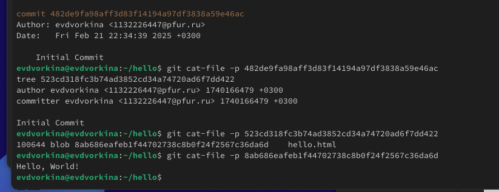

Самостоятельная работа непосредственно с объектами git